# BEL Leroux simulation

Farzana Jahan

June 8, 2020

## BEL Leroux Algorithm

The metropolis hastings algorithm to draw samples of fixed effect $\beta$ and spatial random effects $\psi$ are drawn from simulated data set. Some data are generated as follows:

Response $y$ was generated for each of the 2147 small reas across Australia. the spatial information to calculate the neighbourhood matrix are available to us.

```
## To access larger datasets in this package, install the spDataLarge
## package with: `install.packages('spDataLarge')`
```

```
## [1] "nb"
```

## Checking the output keeping psi fixed

To check the algorithm performance, we are not sampling the spatial random effect, keeping it fixed to the initial value. For skipping the burnin and checking the algorithm, we have initialised betas to its true value (intercept= 7, slope = 14).

The results of the algorithm are as follows:

```
## [1] "intercept"
```

```
##    Min. 1st Qu.  Median    Mean 3rd Qu.    Max.
##   6.665   6.825   6.942   6.905   6.983   7.037
```

```
## [1] "slope"
```

```
##    Min. 1st Qu.  Median    Mean 3rd Qu.    Max.
##   13.95   14.05   14.12   14.20   14.35   14.68
```

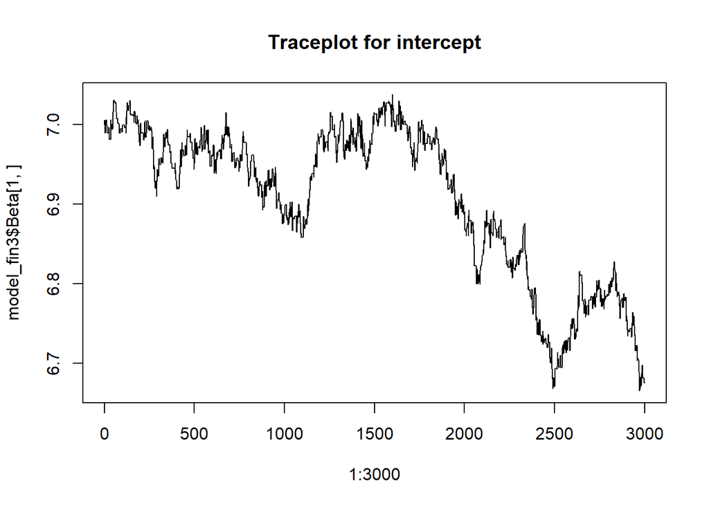

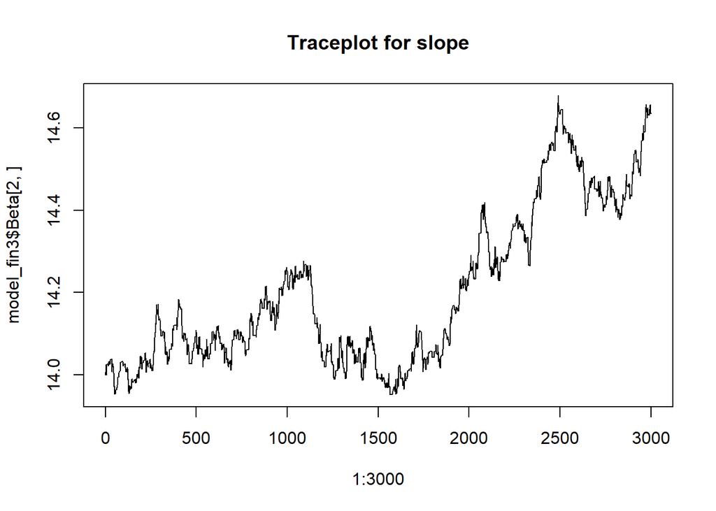

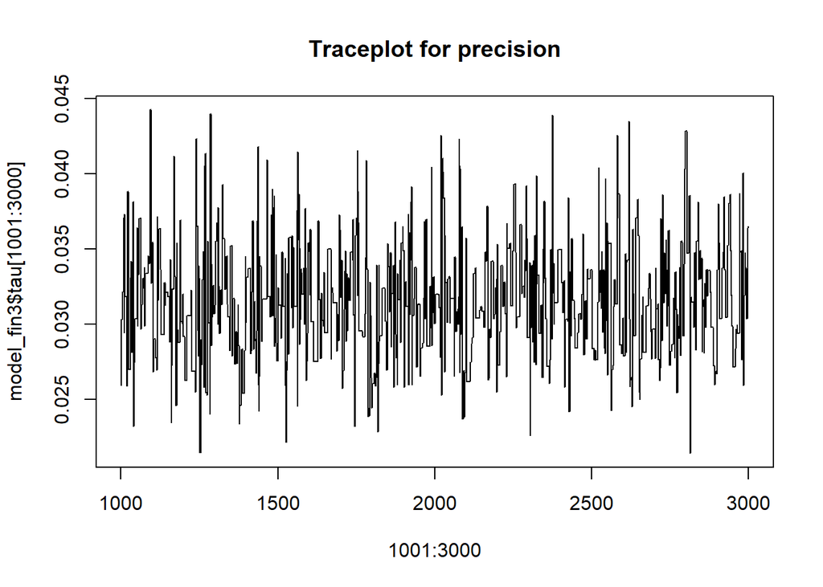

```
## [1] "Precision paramter"
```

```
##    Min. 1st Qu.  Median    Mean 3rd Qu.    Max.
## 0.02142 0.02902 0.03139 0.04830 0.03385 8.29524
```

So, the algorithm was able to estimate the true beta value. Now, we are changing the initial value of beta and taking an initial value from a multivariate normal prior.

```
## [1] "intercept"
```

```
##     Min.  1st Qu.   Median     Mean  3rd Qu.     Max.
## -11.5127   0.6042   1.4687   1.1102   2.1326   3.9576
```

```
## [1] "slope"
```

```
##    Min. 1st Qu.  Median    Mean 3rd Qu.    Max.
##   11.09   13.71   13.99   13.99   14.28   16.22
```

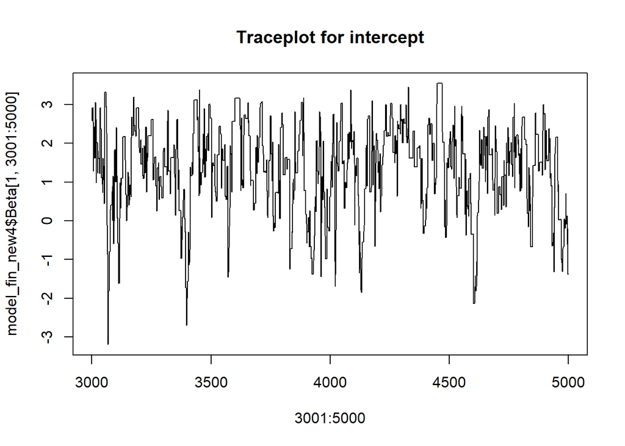

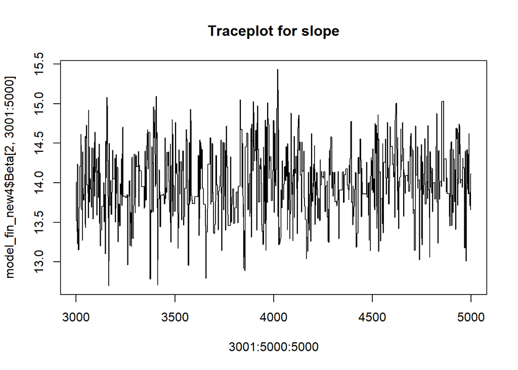

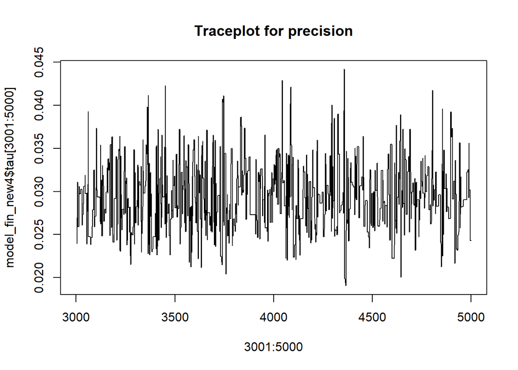

```
## [1] "Precision paramter"
```

```
##    Min. 1st Qu.  Median    Mean 3rd Qu.    Max.
## 0.01689 0.02679 0.02906 0.02932 0.03178 0.04423
```

## Sampling the spatial random effects psi as well

Sampling the psi and initialising beta to its true values.

```
## [1] "intercept"
```

```
##    Min. 1st Qu.  Median    Mean 3rd Qu.    Max.
##   7.400   7.831   7.949   7.938   8.056   8.391
```

```
## [1] "slope"
```

```
##    Min. 1st Qu.  Median    Mean 3rd Qu.    Max.
##   11.31   11.91   12.14   12.16   12.37   13.18
```

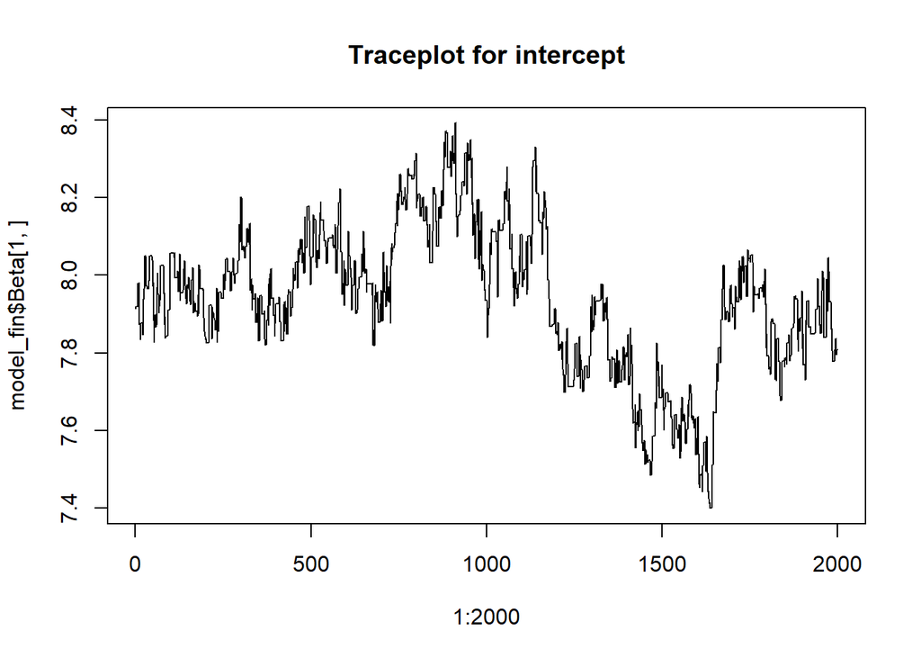

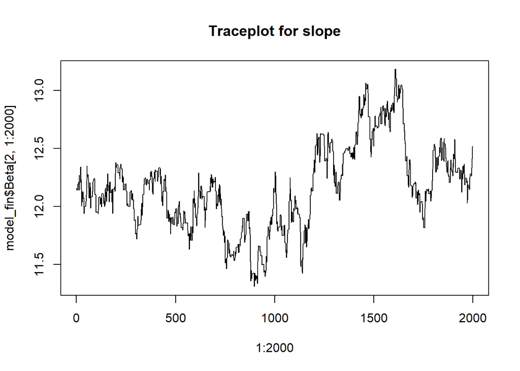

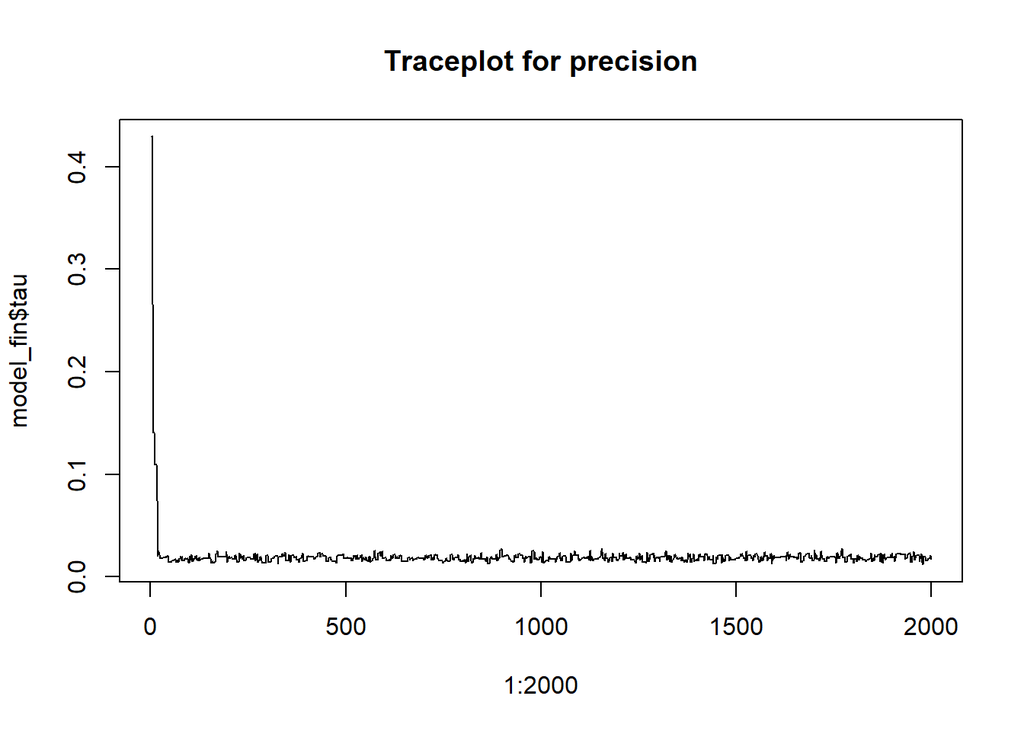

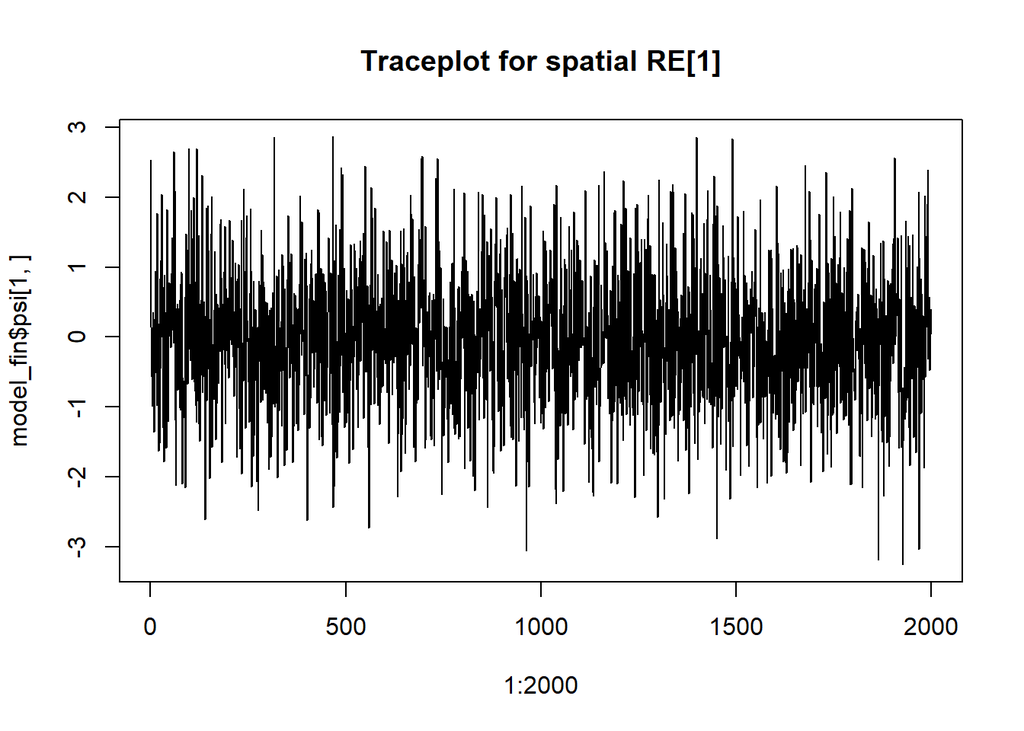

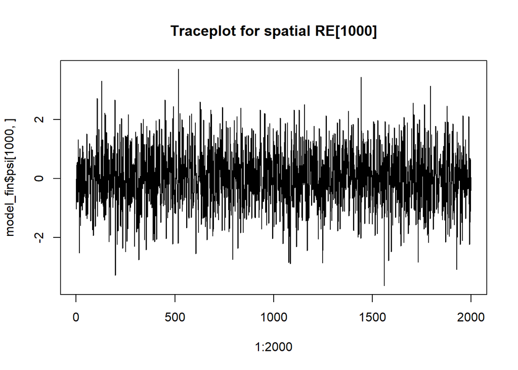

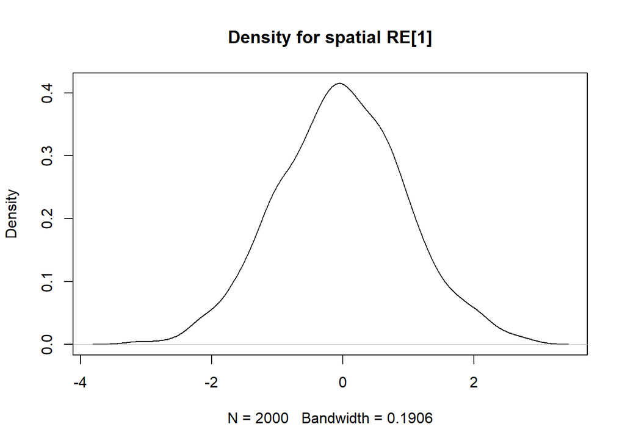

```
## [1] "Precision parameter"
```

```
##    Min. 1st Qu.  Median    Mean 3rd Qu.    Max.
## 0.01182 0.01639 0.01821 0.02002 0.02012 0.42931
```

Now, if we change the initial values of $\beta$ from the true value to randomly generated values from prior distribution, the slope parameter can be estimated fine, but the intercept is not working well. That means there is still some bug in the algorithm that need fixing.

```
## [1] "intercept"
```

```
##     Min.  1st Qu.   Median     Mean  3rd Qu.     Max.
## -31.6567 -19.3799 -15.5351 -16.1877 -13.5301   0.4826
```

```
## [1] "slope"
```

```
##    Min. 1st Qu.  Median    Mean 3rd Qu.    Max.
##  -1.127  12.376  13.768  13.493  14.924  19.557
```

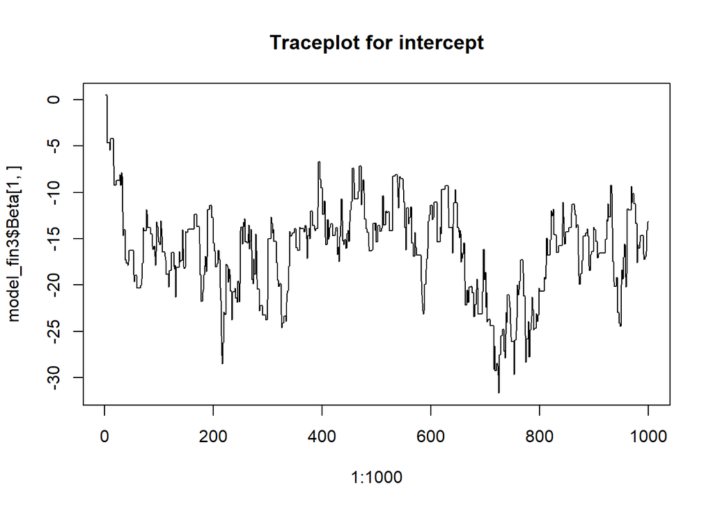

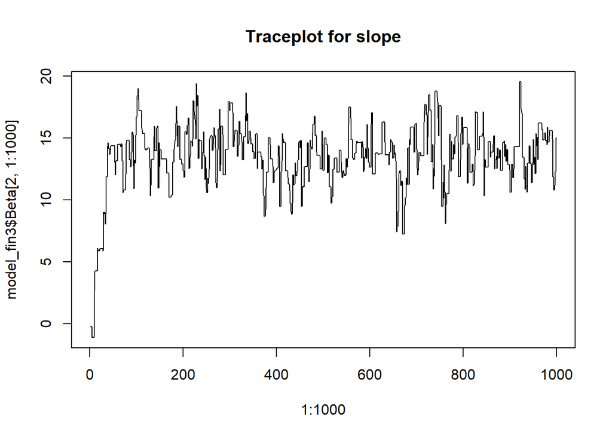

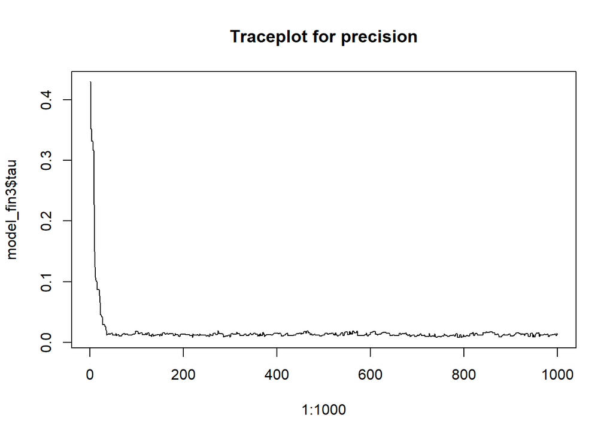

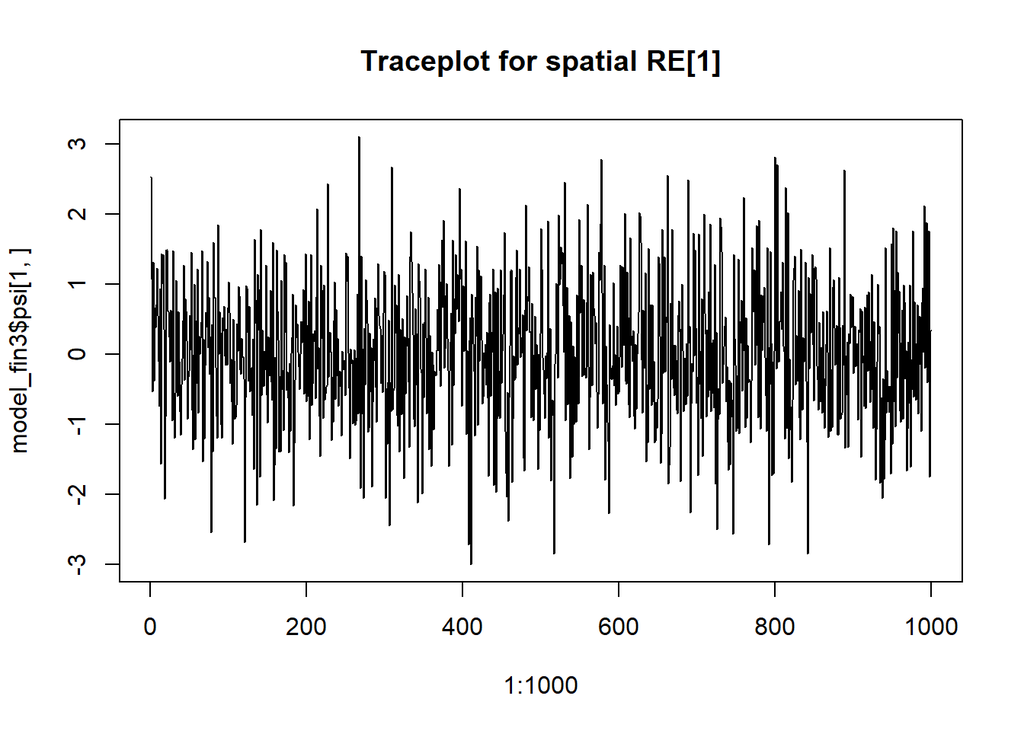

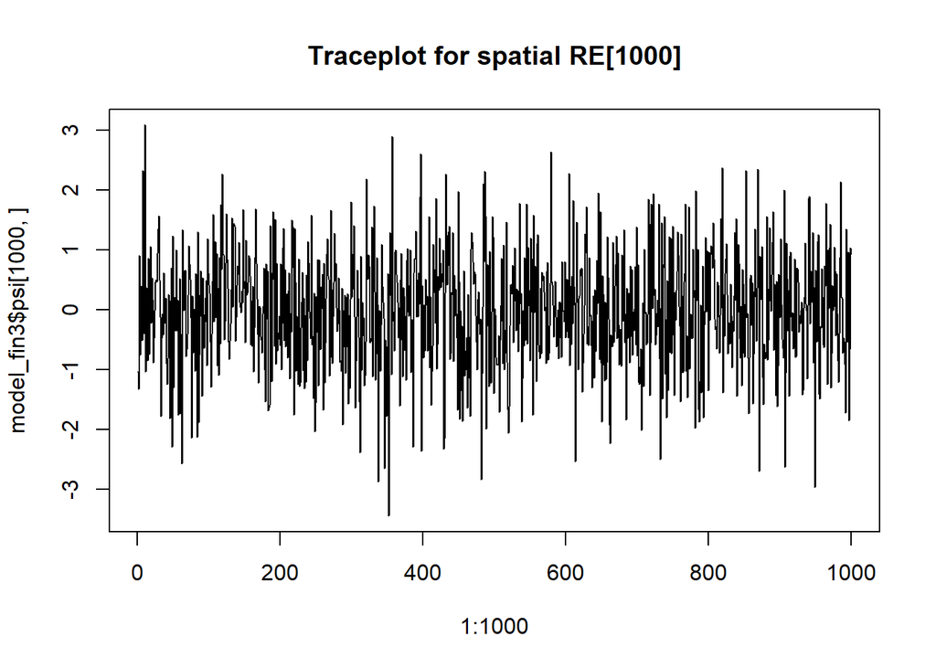

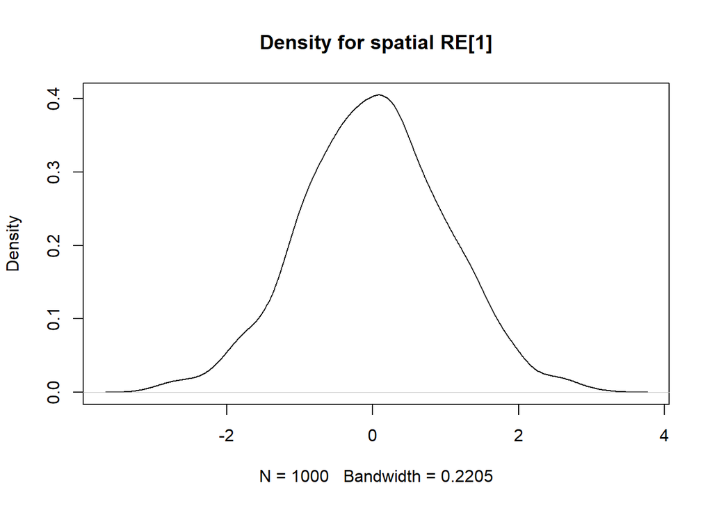

```
## [1] "Precision parameter"
```

```
##     Min.  1st Qu.   Median     Mean  3rd Qu.     Max.
## 0.008262 0.011697 0.013000 0.017313 0.014743 0.429311
```

## MCMC with 100,000 iteration, burnin = 50000

We ran same codes with initial psi set to true value and beta initial randomlt selected from a prior and ran 100,000 iterations. The results below shows that we still got problem in sampling the intercept as the intercept values are not even closer to the true value (7). The slope is working well, but it also performed well in case of 1000 or 10000 iteration. We need to fix this problem somehow to move forward.

```
## [1] "intercept"
```

```
##     Min.  1st Qu.   Median     Mean  3rd Qu.     Max.
## -39.6241 -20.0160 -16.7282 -16.9644 -13.6791   0.4826
```

```
## [1] "slope"
```

```
##    Min. 1st Qu.  Median    Mean 3rd Qu.    Max.
## -0.2353 12.3250 13.5956 13.5966 14.8528 23.8681
```

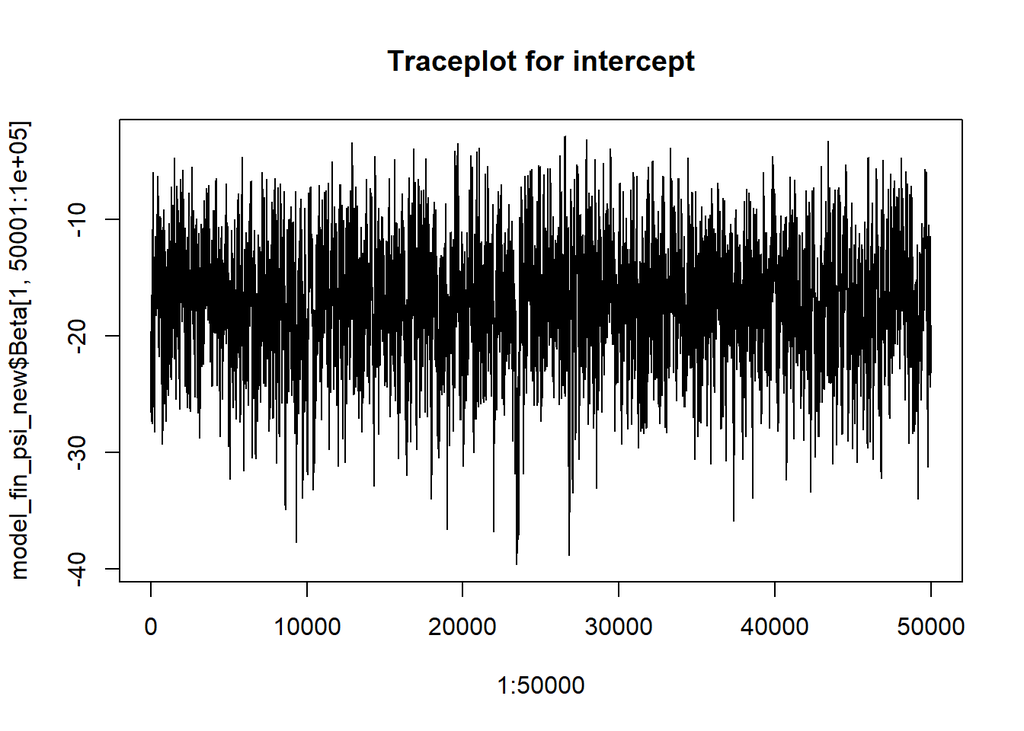

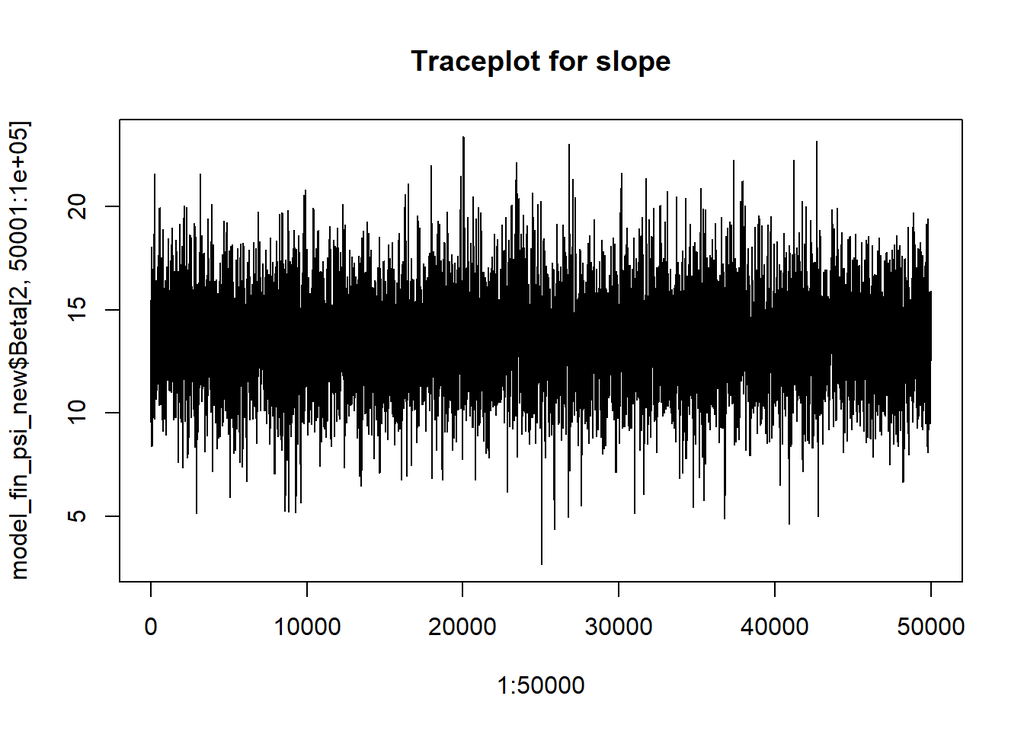

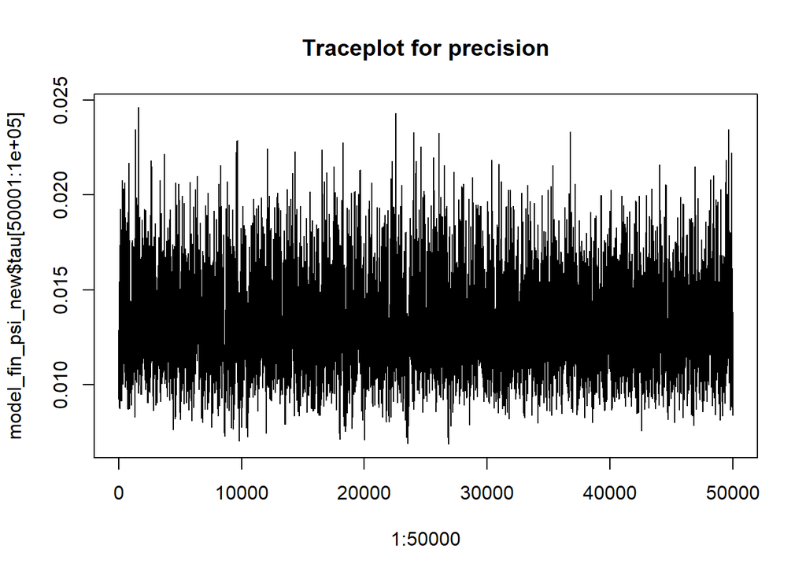

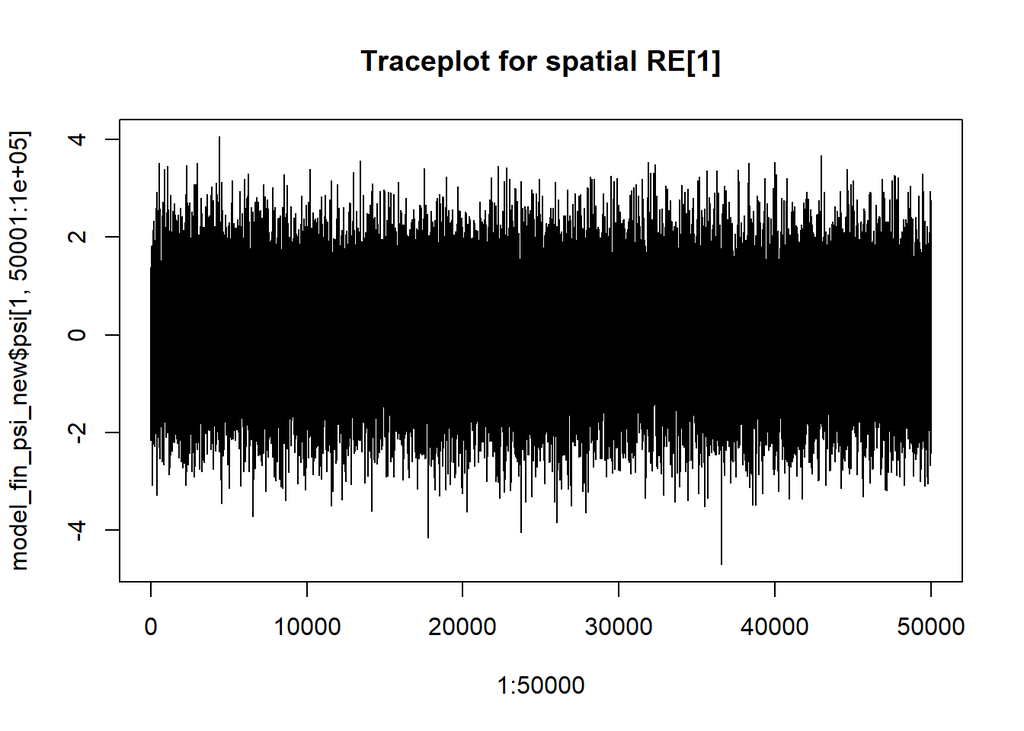

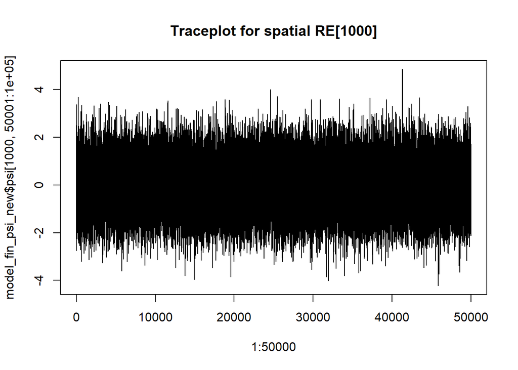

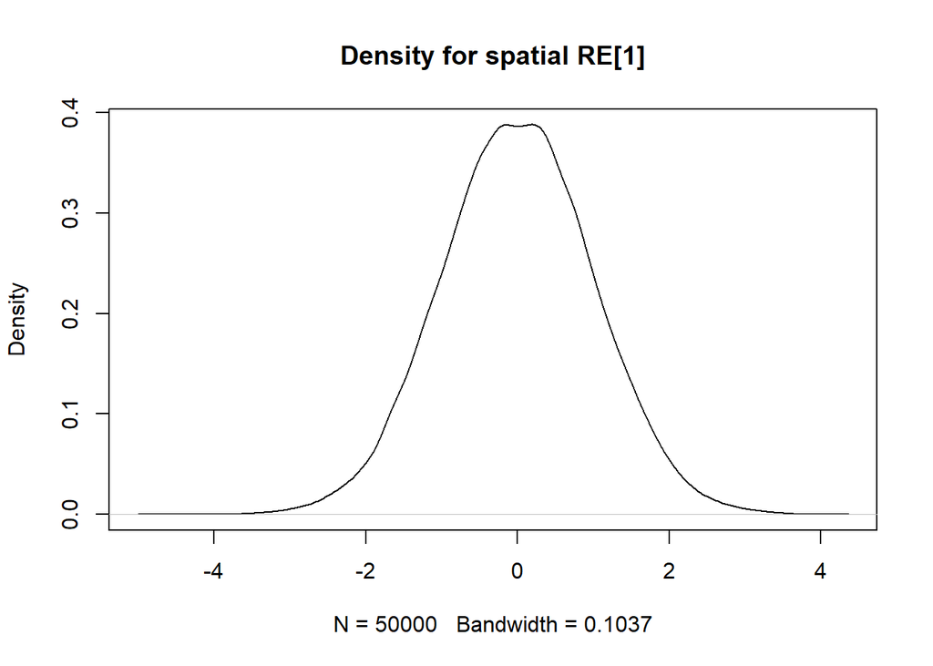

```
## [1] "Precision parameter"
```

```
##     Min.  1st Qu.   Median     Mean  3rd Qu.     Max.
## 0.006718 0.011647 0.012966 0.013230 0.014523 0.429311
```

## Using Debugged codes

We have debugged the codes and now the algorithm can estimate the true values of intercept and slope even with a lower number of iterations. The results after 10000 iteration, burnin=1000 ( $\psi$ still taking true value as initial and variance is known). The summary estimates look good as they are near the true values of regression coefficients. But since this is for a smaller number of iterations, the chain did not converge. We can run longer chains to see if they converge.

```
## [1] "intercept"
```

```
##    Min. 1st Qu.  Median    Mean 3rd Qu.    Max.
##  -1.666   5.827   7.330   7.152   8.045  12.067
```

```
## [1] "slope"
```

```
##      Min.   1st Qu.    Median      Mean   3rd Qu.      Max.
## -0.009094 11.984718 13.399331 13.682064 16.246207 20.850844
```

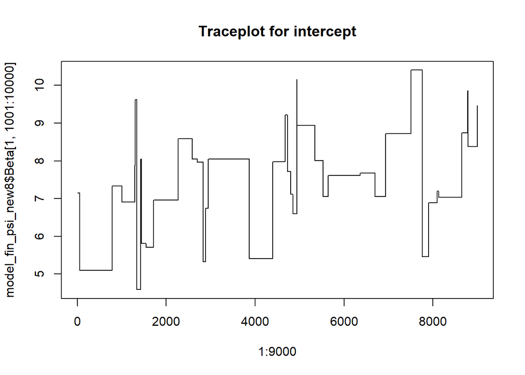

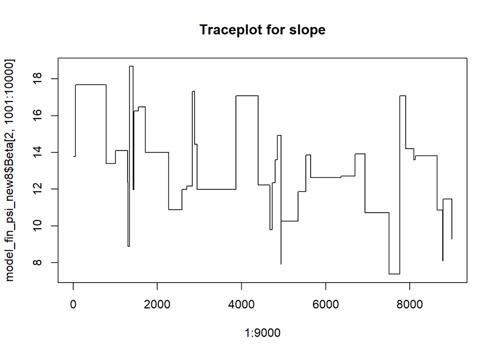

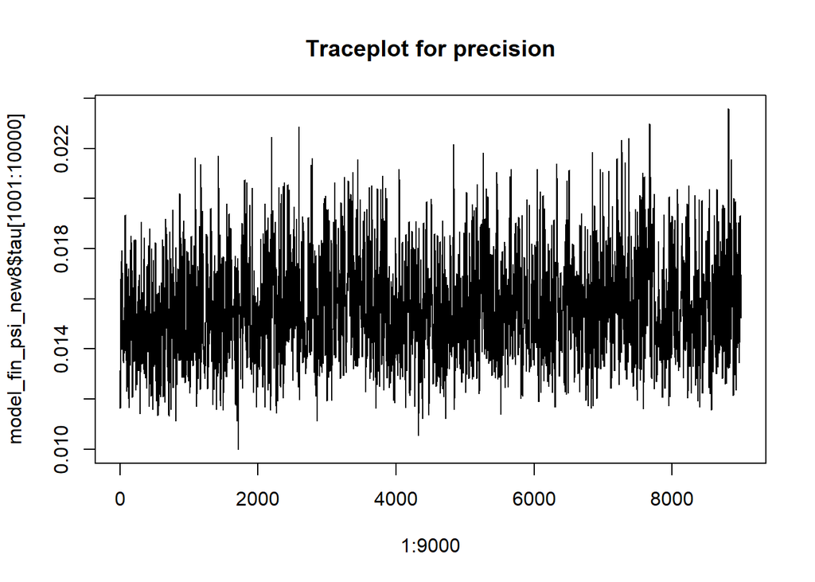

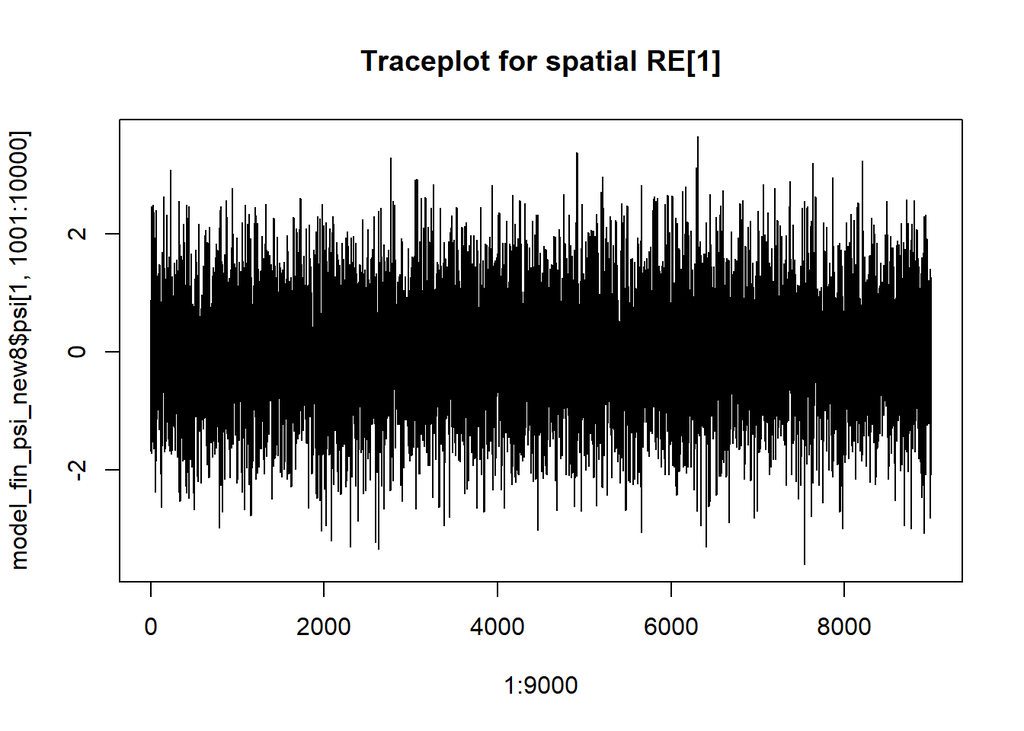

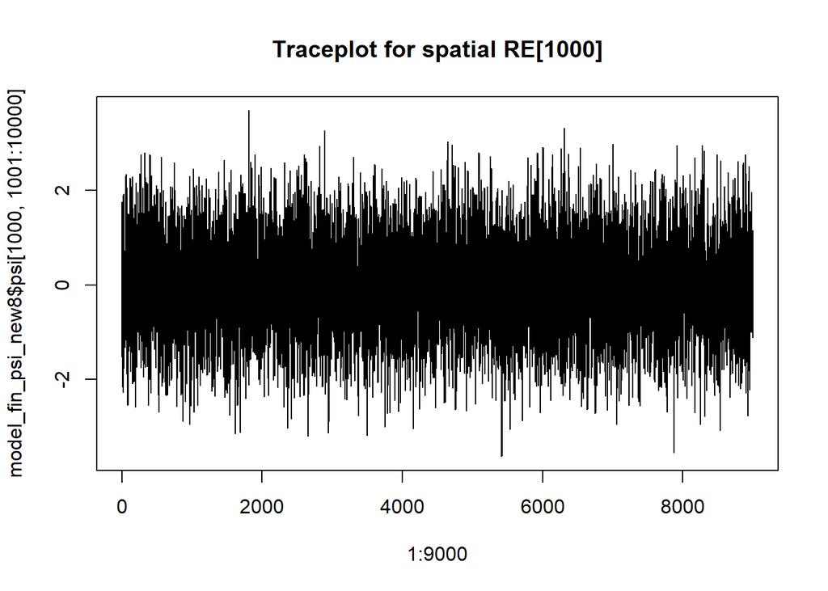

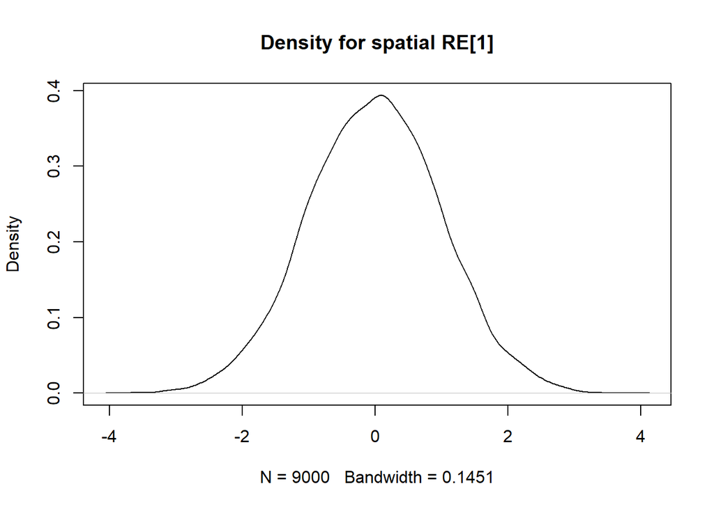

```
## [1] "Precision parameter"
```

```
##     Min.  1st Qu.   Median     Mean  3rd Qu.     Max.
## 0.009987 0.014084 0.015321 0.017827 0.016772 2.239027
```